# team

Tanner Boyle & Hunter Rose

2/25/2020

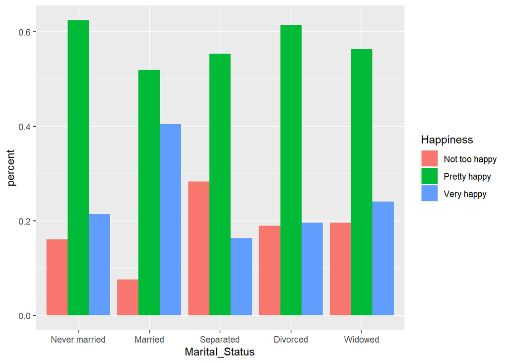

```r
Problem1_DF %>%
  ggplot(aes(fill=Happiness, x=Marital_Status, y=percent)) +
  geom_bar(position="dodge", stat="identity")
```

The takeaway from this graph to us is that the unhappiest people are those that are separated – while divorced and widowed don’t appear to be that much higher than the never-married crowd.

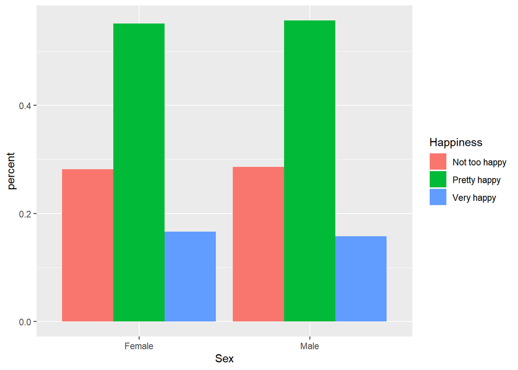

```r
Problem2_DF %>%
  ggplot(aes(fill=Happiness, x=Sex, y=percent)) +
  geom_bar(position="dodge", stat="identity")
```

We don’t think that Sex has an impact on the happiness of Separated adults. Percentages appear to be pretty similar across the board.

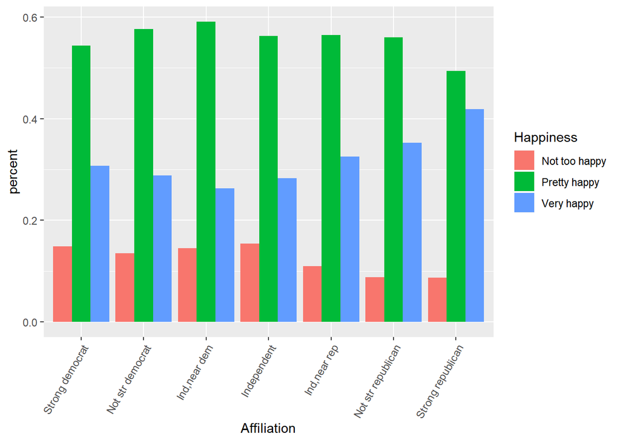

```r
Problem3_DF %>%
  ggplot(aes(fill=Happiness, x=Affiliation, y=percent)) +
  geom_bar(position="dodge", stat="identity") +
  theme(axis.text.x = element_text(angle=60, hjust = 1))
```

Yes, we think that there is a fairly clear trend of Left-Leaning respondents reporting lower levels of happiness. Specifically, the “Very happy” column appears to have a sort of parabola effect where Right-Leaning respondents are reporting the highest percentages of “Very happy” and lowest percentages of “Not too happy”.

#Problem 4.1: How does happiness levels compare between gender regardless of all other factors?

```r
Problem4.1_DF <- dat %>%
  filter(!is.na(Year),
         !is.na(Happiness),
         !is.na(Sex)) %>%
  group_by(Sex,Happiness) %>%
  summarise(n=n()) %>%
  as_data_frame() %>%
  group_by(Sex) %>%
  mutate(percent = n/sum(n))
```

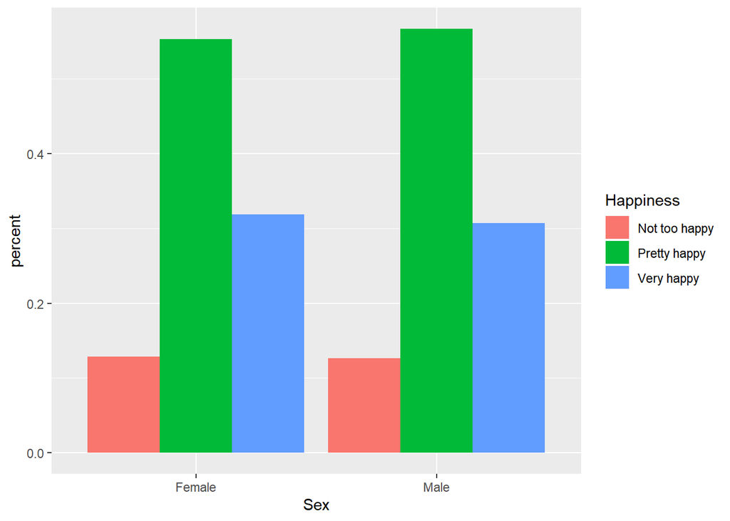

```r
Problem4.1_DF %>%
  ggplot(aes(fill=Happiness, y=percent, x=Sex)) + geom_bar(position="dodge", stat="identity")
```

We can see that Male and Females have relatively the same amount of happiness levels. Females have a few more very happy people while males have a few more Pretty happy people.

#Problem 4.2: What is the gender ratio in each political group?

```r
Problem4.2_DF <- dat %>%
  filter(!is.na(Happiness),
         !is.na(Affiliation),
         !is.na(Sex)) %>%
  group_by(Happiness, Affiliation, Sex) %>%
  summarise(n=n())%>%
  as_data_frame() %>%
  group_by(Sex) %>%
  mutate(percent=n/sum(n))
```

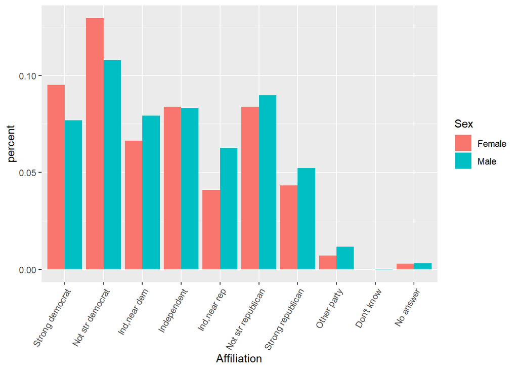

```r
Problem4.2_DF %>%
  ggplot(aes(fill=Sex, y=percent, x=Affiliation)) + geom_bar(position="dodge", stat="identity") + theme(axis.text.x = element_text(angle=60, hjust = 1))
```

This shows us that there are more people who identify with the democratic party than any other. This is interesting because when we looked at the happiness level by each political affiliation, we saw that republicans tended to be more happy. This shows that the republican are in a slight minority to the democrats, and tend to be happier.

```r
dat1 <- read_xls('GSS_1.xls')
str(dat1)
```

```
## Classes 'tbl_df', 'tbl' and 'data.frame':    64816 obs. of  9 variables:
##  $ Gss year for this respondent       : num  1972 1972 1972 1972 1972 ...
##  $ Respondent id number               : num  1 2 3 4 5 6 7 8 9 10 ...
##  $ Number of hours usually work a week: chr  "Not applicable" "Not applicable" "Not applicable" "Not applicable" ...
##  $ Marital status                     : chr  "Never married" "Married" "Married" "Married" ...
##  $ Respondents sex                    : chr  "Female" "Male" "Female" "Female" ...
##  $ Respondents income                 : chr  "Not applicable" "Not applicable" "Not applicable" "Not applicable" ...
##  $ Political party affiliation        : chr  "Ind,near dem" "Not str democrat" "Independent" "Not str democrat" ...
##  $ General happiness                  : chr  "Not too happy" "Not too happy" "Pretty happy" "Not too happy" ...
##  $ Ballot used for interview          : chr  "Not applicable" "Not applicable" "Not applicable" "Not applicable" ...
```

```r
names(dat1) <- c("Year", "ID", "Hours_worked", "Marital_Status", "Sex", "Income", "Affiliation", "Happiness", "Ballot")

dat1$Year <- factor(dat1$Year)

dat1$Marital_Status <- factor(dat1$Marital_Status, levels= c("No answer", "Never married", "Married", "Separated", "Divorced", "Widowed"))

dat1$Affiliation <- factor(dat1$Affiliation, levels= c("Strong democrat", "Not str democrat",
                                                     "Ind,near dem","Independent", "Ind,near rep",
                                                     "Not str republican", "Strong republican",
                                                     "Other party", "Don't know", "No answer"))

dat1$Happiness <- factor(dat1$Happiness, levels = c("Not too happy", "Pretty happy", "Very happy"))
```

Problem 4.3: How does income relate to happiness?

```r
Problem4.3_DF <- dat1 %>%
  filter(!is.na(Happiness),
         !is.na(Income),
         !is.na(Year),
         Income != "Not applicable") %>%
  group_by(Happiness, Income) %>%
  summarise(n=n()) %>%
  as_data_frame() %>%
  group_by(Happiness) %>%
  mutate(percent=n/sum(n))
```

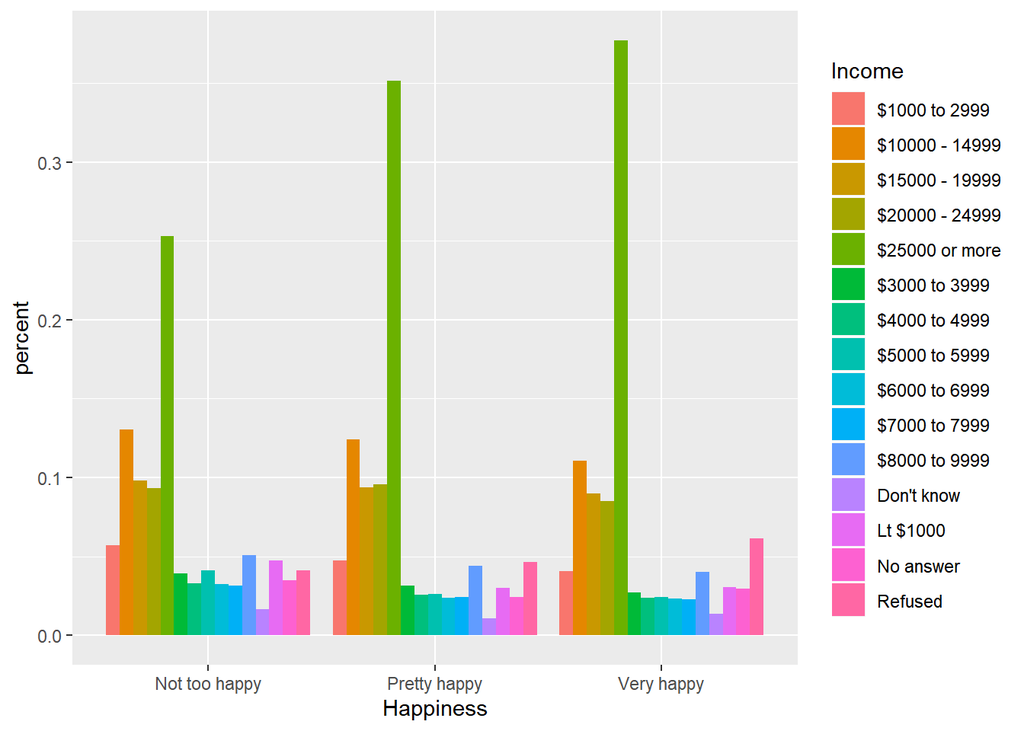

```r
Problem4.3_DF %>%
  ggplot(aes(fill=Income, x=Happiness, y=percent)) + geom_bar(position="dodge", stat="identity")
```

This graph shows us that people in the very happy category tend have a similar income distribution to the other classes. The largest income class (25000 or more) is the largest group for each happiness level but gets higher as happiness goes up. The lower income distributions are very similar there is an increase in the lower income classes as happiness decreases.

```r
Problem4.4_DF <- dat1 %>%
  filter(!is.na(Happiness),
         !is.na(Hours_worked),
         !is.na(Year),
         Hours_worked != "Not applicable",
         Hours_worked != "No answer") %>%
  group_by(Happiness, Hours_worked) %>%
  summarise(n=n()) %>%
  as_data_frame() %>%
  group_by(Happiness) %>%
  mutate(percent=n/sum(n))
```

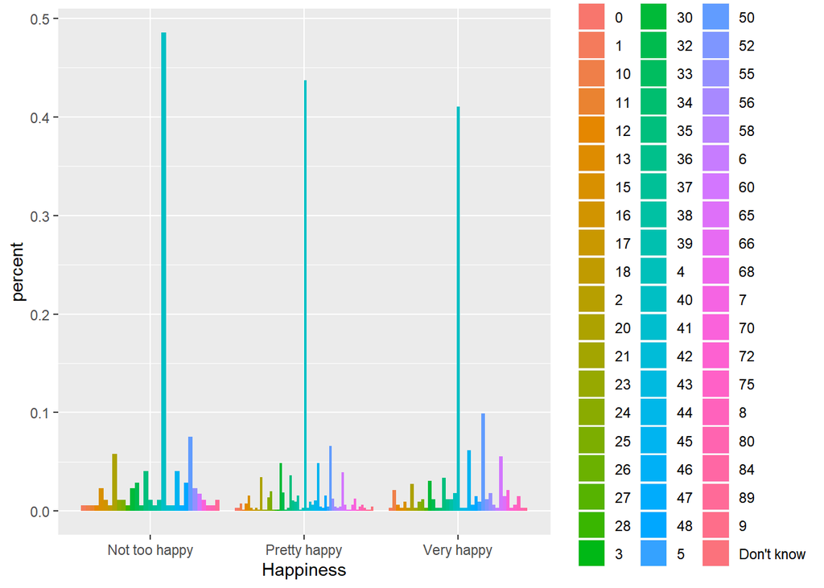

```r
Problem4.4_DF %>%
  ggplot(aes(fill=Hours_worked, y=percent, x=Happiness)) + geom_bar(position="dodge", stat="identity")
```